# Gothic Textual Data

Margaret Butler

12/3/2019

## Looking at Gothic Literature

Downloading books I want to look at from the gutenbergr package. Books I am looking at in this are *Frankenstein*, *The Strange Case of Dr. Jekyll and Mr. Hyde*, *Carmilla*, *The Phantom of the Opera*, and *Dracula*.

## Gutenberg Book ID Numbers

1. Frankenstein 84
2. The Strange Case of Dr. Jekyll and Mr. Hyde 43
3. Carmilla 10007
4. The Phantom of the Opera 175
5. Dracula 345

```r
gothic <- gutenberg_download(c(84, 43, 10007, 175, 345), meta_fields = "title")

gothic$row_num <- seq.int(nrow(gothic))


frankenstein <- gutenberg_download(84)
jekyllhyde <- gutenberg_download(43)
carmilla <- gutenberg_download(10007)
phantom <- gutenberg_download(175)
dracula <- gutenberg_download(345)

## downloading the books into one big data set and then into separate data sets
## I discovered later that I did'nt need to download the texts separately but I'm leaving them in here for now

tidy_gothic <- gothic %>%
  unnest_tokens(word, text) %>%
  anti_join(stop_words)

messy_gothic <- gothic %>%
  unnest_tokens(word, text)

## need a messy_gothic and a separate tidy_gothic because one includes the pronouns I want to count while the other removes pronouns. I'm looking at both.

tidy_frankenstein <- frankenstein %>%
  unnest_tokens(word, text) %>%
  anti_join(stop_words)

tidy_jekyllhyde <- jekyllhyde %>%
  unnest_tokens(word, text) %>%
  anti_join(stop_words)

tidy_carmilla <- carmilla %>%
  unnest_tokens(word, text) %>%
  anti_join(stop_words)

tidy_phantom <- phantom %>%
  unnest_tokens(word, text) %>%
  anti_join(stop_words)

tidy_dracula <- dracula %>%
  unnest_tokens(word, text) %>%
  anti_join(stop_words)

## tidying words so I can pick through them at my leisure
## I am a goofball and realized that the reason I cannot analyze the pronoun usage is because stop_words removes pronouns...
```

```r
sentiment_time <- tidy_gothic %>%
  inner_join(get_sentiments("bing")) %>%
  count(title, index = row_num %/% 80, sentiment) %>%
  spread(sentiment, n, fill = 0) %>%
  mutate(sentiment = positive - negative)
```

```r
sentiment_dist <- ggplot(sentiment_time, aes(index, sentiment, fill = title)) +
  geom_col(show.legend = FALSE) +
  facet_wrap(~title, ncol = 2, scales = "free_x")

write_rds(sentiment_time, "gothiclit/sentiment_time.rds")
```

I want to map pronoun usage and negative sentiment across the books to see if I can track monstrosity, but I genuinely have no idea how to do all of that. So, I am frustrated.

```r
tidy_gothic %>%
  count(word, sort = TRUE)
```

```
## # A tibble: 15,588 x 2
##    word          n
##    <chr>     <int>
##  1 time        788
##  2 night       567
##  3 eyes        493
##  4 door        469
##  5 day         428
##  6 hand        415
##  7 christine   397
##  8 dear        383
##  9 life        380
## 10 raoul       341
## # … with 15,578 more rows
```

```r
## checking the most common words across all five texts
```

Looking for words we associate with monstrosity.

*The Phantom of the Opera* skews the data because Christine and Raoul are in the top ten most frequent words! Moving on to look at each book individually.

```r
tidy_frank <- tidy_frankenstein %>%
   count(word, sort = TRUE)

## words that are unique to Frankenstein due to status as names: elizabeth

tidy_jek <- tidy_jekyllhyde %>%
  count(word, sort = TRUE)

## words that are unique to Jekyll and Hyde due to status as names: poole, utterson, jekyll, hyde

tidy_carm <- tidy_carmilla %>%
  count(word, sort = TRUE)

## words that are unique to Carmilla due to status as names: carmilla

tidy_drac <- tidy_dracula %>%
  count(word, sort = TRUE)

## words that are unique to Dracula due to status as names: van, helsing, lucy, mina, jonathan

tidy_phan <- tidy_phantom %>%
  count(word, sort = TRUE)

## words that are unique to Phantom due to status as names: christine, raoul, erik, richard
```

```r
no_names <- messy_gothic %>%
  filter(word != "elizabeth") %>%
  filter(word != "poole") %>%
  filter(word != "utterson") %>%
  filter(word != "jekyll") %>%
  filter(word != "van") %>%
  filter(word != "helsing") %>%
  filter(word != "carmilla") %>%
  filter(word != "hyde") %>%
  filter(word != "lucy") %>%
  filter(word != "mina") %>%
  filter(word != "christine") %>%
  filter(word != "raoul") %>%
  filter(word != "erik") %>%
  filter(word != "richard") %>%
  filter(word != "jonathan") %>%
  filter(word != "arthur") %>%
  filter(word != "de") %>%
  filter(word != "karstein") %>%
  filter(word != "mircalla") %>%
  filter(word != "millarca") %>%
  rename(book = title)

## removing de because it is a french part of speech
```

```r
## tidying data set for density plot that will look at most common words as well as pronouns

dense_gothic <- messy_gothic %>%
  rename(novel = title) %>%
  count(novel, index = row_num %/% 100, word)

write_rds(dense_gothic, "gothiclit/dense_gothic.rds")
```

```r
## tidying data for regression

reg_gothic <- messy_gothic %>%
  rename(books = title) %>%
  rename(words = word)

write_rds(reg_gothic, "gothiclit/reg_gothic.rds")
```

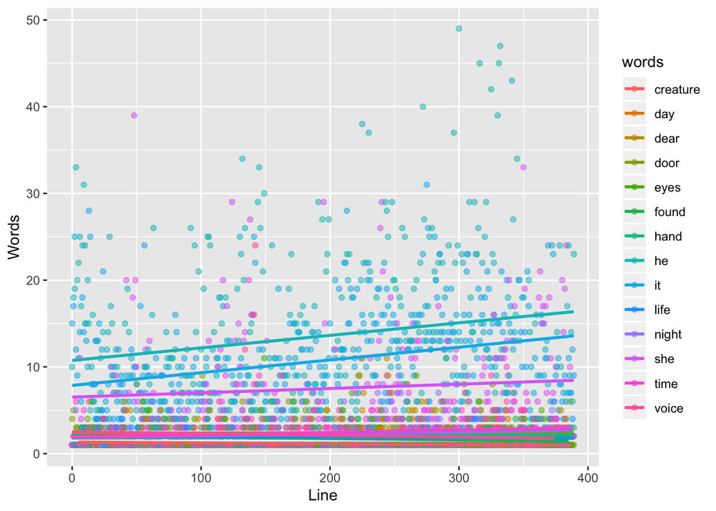

```r
reg_gothic %>%
            filter(words == "time" |
                    words == "night" |
                    words == "eyes" |
                    words == "day" |
                    words == "door" |
                    words == "hand" |
                    words == "dear" |
                    words == "life" |
                    words == "found" |
                    words == "voice" |
                    words == "he" |
                    words == "she" |
                    words == "it" |
                    words == "creature") %>%
  count(books, index = row_num %/% 100, words) %>%
            ggplot(aes(index, n, color = words)) +
            geom_point(alpha = 0.5) +
            geom_smooth(method = "lm", se = FALSE) +
            labs(
                x = "Line",
                y = "Words"
            )
```

```r
## testing my regression to see if I could get it to work
```

```r
cloudish_gothic <- no_names

write_rds(cloudish_gothic, "gothiclit/cloudish_gothic.rds")


write_rds(messy_gothic, "gothiclit/messy_gothic.rds")
```

```r
write_rds(tidy_gothic, "gothiclit/tidy_gothic.rds")


## made dirctory for gothic shiny app and made file to use in said shiny app
```

There is terrible inconsistency between my rmd and the shiny app. Goes from gothic_project to gothiclit to gothicproject.